# Random Forest - Grinds Exploration on Client Retention

Alex Heck, Tom Zwiller, Giulia Neves Monteiro, Aziz Al Mezraani, Madison Bradley

2025-01-27

## Importing the relevant packages needed:

## Data Preparation and Cleaning

```r
#Reading in the data
returning_data = read.csv("C:\\Users\\Graduate\\Downloads\\sales_2023-12-01_2024-11-01_Grinds Confidential.csv", header = TRUE)

#Removing the net_quantity rows that are less than 0. We kept exactly 0 because that suggests returns
returning_data <- returning_data[returning_data$net_quantity >= 0, ]

#this chunk focused on removing any weird characters from the data
colnames(returning_data) <- make.names(colnames(returning_data))
Encoding(returning_data$product_title) <- "UTF-8"
returning_data$product_title <- iconv(returning_data$product_title,
                                      "UTF-8", "UTF-8", sub = "")
returning_data$product_title <- gsub("^\\W\\s", "", returning_data$product_title, perl = TRUE)

#and this list allowed us to find any international locations and label them as such
us_states <- c("Alabama", "Alaska", "Arizona", "Arkansas", "California", "Colorado", "Connecticut", "Delaware", "Florida", "Georgia", "Hawaii", "Idaho", "Illinois", "Indiana", "Iowa", "Kansas", "Kentucky", "Louisiana", "Maine", "Maryland", "Massachusetts", "Michigan", "Minnesota", "Mississippi", "Missouri", "Montana", "Nebraska", "Nevada", "New Hampshire", "New Jersey", "New Mexico", "New York", "North Carolina", "North Dakota", "Ohio", "Oklahoma", "Oregon", "Pennsylvania", "Rhode Island", "South Carolina", "South Dakota", "Tennessee", "Texas", "Utah", "Vermont", "Virginia", "Washington", "West Virginia", "Wisconsin", "Wyoming")

#if the region doesn't exist in our list, we are labeling it as 'international'
returning_data$billing_region <- ifelse(!(returning_data$billing_region %in% us_states), "International", returning_data$billing_region)

# Convert all product titles to lowercase to standardize the data
returning_data <- returning_data[returning_data$product_vendor != "", ]

# Convert all product titles to lowercase to standardize the data
returning_data$product_title <- tolower(returning_data$product_title)

# Rename specific product titles for consistency
returning_data$product_title[returning_data$product_title == 'grinds coffee pouches - vanilla'] <- 'vanilla'
returning_data$product_title[returning_data$product_title == 'grinds coffee pouches - 3pack variety with double mocha, sweet mint and cinnamon roll'] <- '3 pack variety'
returning_data$product_title[returning_data$product_title == '3-pack energy sampler'] <- '3 pack energy sampler'

# Getting rid of the dashes
returning_data$product_title <- gsub("-.*", "", returning_data$product_title)

# Convert product titles to title case for better readability
returning_data$product_title <- str_to_title(returning_data$product_title)

# Removing the spaces
returning_data$product_title <- gsub(" ", "", returning_data$product_title)

# Remove '100% off'
returning_data$product_title <- gsub("\\(100%off\\)", "", returning_data$product_title, ignore.case = TRUE)

# View the result
head(returning_data)
```

```
##   product_title        product_vendor  customer_id customer_type  billing_city
## 1   BlackCoffee                grinds 3.004030e+12     Returning    Woodbridge
## 2  OrangeCitrus Grinds Coffee Pouches 2.982320e+12     Returning New Braunfels
## 3   Wintergreen                grinds 5.406090e+12     Returning Spring Valley
## 4     Spearmint                grinds 6.122690e+12     Returning       Tamarac
## 5  CinnamonRoll                grinds 3.347290e+12     Returning      Beatrice
## 6   BlackCoffee                grinds 4.953978e+09     Returning        Austin
##   billing_region net_quantity gross_sales discounts returns net_sales  taxes
## 1       Virginia          340     2023.00   -159.65       0   1863.35   0.00
## 2          Texas          335     1490.75      0.00       0   1490.75   0.00
## 3     California          300     1785.00      0.00       0   1785.00 165.05
## 4        Florida          220     1113.20      0.00       0   1113.20   0.00
## 5       Nebraska          220     1113.20      0.00       0   1113.20   0.00
## 6          Texas          202     1031.02      0.00       0   1031.02   0.00
##   total_sales
## 1     1863.35
## 2     1490.75
## 3     1950.05
## 4     1113.20
## 5     1113.20
## 6     1031.02
```

```r
# Viewing the unique titles
unique(returning_data$product_title)
```

```
##  [1] "BlackCoffee"              "OrangeCitrus"
##  [3] "Wintergreen"              "Spearmint"
##  [5] "CinnamonRoll"             "Caramel"
##  [7] "MintChocolate"            "Vanilla"
##  [9] "DoubleMocha"              "NewOrleansStyle"
## [11] "DoubleShotEspresso"       "BestFlavorsPack"
## [13] "PumpkinSpice"             "CinnamonWhiskey"
## [15] "IrishCream"               "Peach"
## [17] "SweetMint"                "RootBeer"
## [19] "BlackOps:Wintergreen"     "MissionFuelMocha"
## [21] "SaltedCaramel"            "SourApple"
## [23] "KentuckyBourbon"          "HabaneroMint"
## [25] "BirthdayCake"             "PeachEnergy"
## [27] "CoffeeStout"              "6CanSampler"
## [29] "Hazelnut"                 "Peppermint"
## [31] "PeppermintMocha"          "ThinRedLine2xMocha"
## [33] "NewYear'sResolutionsPack" "AmericanMint"
## [35] "RedEyeEspresso"           "ThinBlueLineEspresso"
## [37] "AllNewPeach"              "SpicyMango"
## [39] "OrangeDreamsicle"         "PinkSweetMint"
## [41] "3PackEnergySampler"       "PeanutButterCup"
## [43] "ElectricOrange"           "WintergreenEnergy"
## [45] "GrindsMetalCan"           "SweetMintGolf"
## [47] "EctoOrange"               "BlackGrindsKoozie"
## [49] "12OzGrindsTumbler"        "YellowKoozie"
## [51] "SteakSauce"               "3PackVariety"
## [53] "GrindsHandcraftedMug"     "Tiktok6CanSampler"
## [55] "GrindsFlask"              "GrindsPintGlass"
## [57] "BlackFridayTop"           "Cherry"
## [59] "Mocha"
```

```r
# Setting our random seed
set.seed(7)

# Making the strings into vectors
returning_data$product_vendor <- as.factor(returning_data$product_vendor)
returning_data$customer_type <- as.factor(returning_data$customer_type)
returning_data$billing_region <- as.factor(returning_data$billing_region)

# Split our data based on the customer type
split_data <- stratified(returning_data,
                        group = c("customer_type"),
                        size = 0.8, bothSets = TRUE)

# Removing the NA values from our training set
train_data <- as.data.frame(na.omit(split_data[[1]]))

# Removing the NA values from our testing set
test_data <- na.omit(split_data[[2]])
```

## Developing First Tree

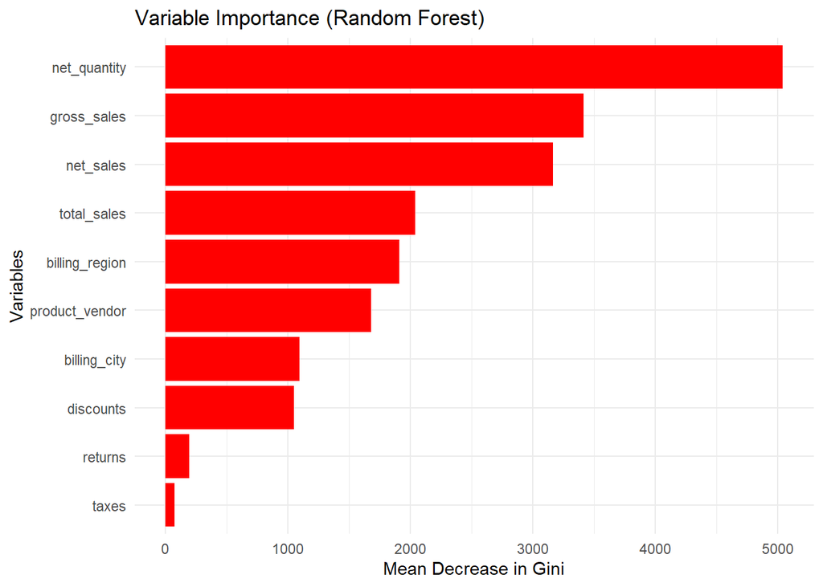

```r
# Making our first tree based on the training data
Tree_1 <- randomForest(customer_type ~ . -product_title -customer_id,
                              data = train_data,
                              mtry = ncol(train_data) * .333,
                              ntree = 150,
                              nodesize = 750)

# Testing our tree
test_1 <- predict(Tree_1, newdata = test_data, type = 'response')

# Comparing it to the original results
tree_1_acc <- confusionMatrix(test_1, test_data$customer_type, positive = 'Returning')

# Getting the important factors from the model
tree_importance <- as.data.frame(Tree_1$importance)

# Writing them out so they can be graphed
tree_importance$Variable <- rownames(tree_importance)

# Visualizing the plot
ggplot(tree_importance, aes(x = reorder(Variable, MeanDecreaseGini), y = MeanDecreaseGini)) +
  geom_bar(stat = "identity", fill = "red") +
  coord_flip() +
  labs(title = "Variable Importance (Random Forest)",
       x = "Variables",
       y = "Mean Decrease in Gini") +
  theme_minimal()
```

The main takeaway from this first tree was to get rid of the taxes and the returns. We also knew we needed to add in the flavors down the road.

## Building the 2nd Tree

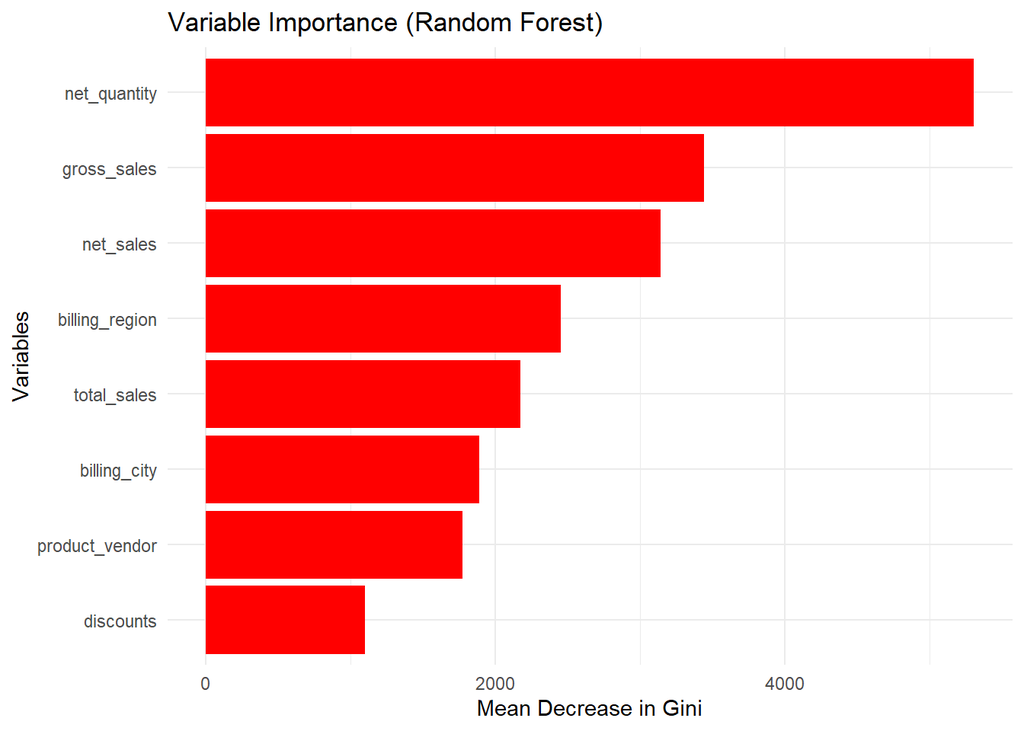

```r
# Creating a Random Forest model to predict customer type
Tree_2 <- randomForest(customer_type ~ .
                       -product_title -customer_id -taxes -returns,
                       data = train_data,
                       mtry = sqrt(ncol(train_data)), # Number of variables to possibly split at each node
                       ntree = 100,                     # Number of trees to grow
                       nodesize = 500)                  # Minimum size of terminal nodes

# Testing the trained Random Forest model on new data
test_2 <- predict(Tree_2, newdata = test_data, type = 'response')

# Evaluating model performance using a confusion matrix
tree_2_acc <- confusionMatrix(test_2, test_data$customer_type, positive = 'Returning')

# Extracting the variable importance of the model
tree_2_importance <- as.data.frame(Tree_2$importance)
tree_2_importance$Variable <- rownames(tree_2_importance) # Creating a variable for better visualization

# Visualizing variable importance using a horizontal bar plot
ggplot(tree_2_importance, aes(x = reorder(Variable, MeanDecreaseGini), y = MeanDecreaseGini)) +
  geom_bar(stat = "identity", fill = "red") +        # Bar chart with red fill
  coord_flip() +                                   # Flipping the coordinates for horizontal bars
  labs(title = "Variable Importance (Random Forest)", # Adding titles and labels
       x = "Variables",
       y = "Mean Decrease in Gini") +
  theme_minimal()                                   # Minimal theme for aesthetics
```

Now that taxes and returns were gone, we felt that everything was fairly significant and the model was as simple as it could reasonably be. Now, to add in the flavors.

The main issue with the flavors was the quantity. There were quite a few when we started, and even when we cleaned the data, it was still above the amount that the random forest felt comfortable using as a factor.

So we had to get rid of a few more products.

## Creating a new set:

```r
# Making a new set
returning_data_2 <- returning_data

# Dropping a combination of temporary flavors, discontinued flavors, and non-flavor based products to reduce the number of products listed
returning_data_2 <- returning_data_2[
                     returning_data_2$product_title != "SteakSauce" &
                     returning_data_2$product_title != "NewYear'sResolutionsPack" &
                     returning_data_2$product_title != "12OzGrindsTumbler" &
                     returning_data_2$product_title != "GrindsHandcraftedMug" &
                     returning_data_2$product_title != "GrindsPintGlass" &
                     returning_data_2$product_title != "GrindsFlask" &
                     returning_data_2$product_title != "BlackFridayTop", ]

# Converting the customer type into 1 and 0s so we can perform regression and return a %
returning_data_2$customer_type <- ifelse(returning_data_2$customer_type == 'Returning', 1, 0)

# Converting products to factors
returning_data_2$product_title <- as.factor(returning_data_2$product_title)
```

```r
# Splitting the dataset based on customer type, stratifying by group
split_data_2 <- stratified(returning_data_2,
                        group = c("customer_type"),     # Stratification by customer type
                        size = 0.8,                     # Training set size as 80%
                        bothSets = TRUE)                # Return both training and test sets

# Creating the training data set, removing any NA values
train_data_2 <- as.data.frame(na.omit(split_data_2[[1]]))

# Creating the testing data set, removing any NA values
test_data_2 <- na.omit(split_data_2[[2]])

# Converting customer_type variable into a factor for modeling
train_data_2$customer_type <- as.factor(train_data_2$customer_type)
```

The product based tree:

```r
Product_Tree <- randomForest(customer_type ~ . -customer_id -taxes -returns,
                              data = train_data_2,
                              mtry = sqrt(ncol(train_data_2)), # Number of variables to possibly split at each node
                              ntree = 150,                       # Number of trees to grow
                              nodesize = 500)                    # Minimum size of terminal nodes

# Using the product-based model to predict customer type on test data
test_3 <- predict(Product_Tree, newdata = test_data_2)

# Transforming predictions to numeric for further processing
test_3n <- as.numeric(test_3) - 1

# Scaling into 1 and 0 for accurate grading
pred_3_fact <- as.factor(ifelse(test_3n >= 0.5, "1", "0"))
```

Evaluating and visualizing the model:

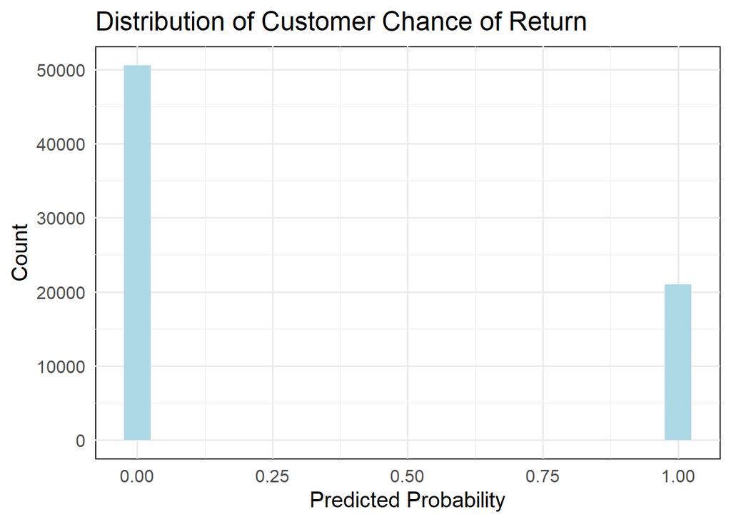

```r
# Evaluating model performance using a confusion matrix
tree_3_acc <- confusionMatrix(pred_3_fact, as.factor(test_data_2$customer_type), positive = '1')

# Plotting the predicted probabilities to visualize customer return likelihood
customer_dist <- ggplot(data = data.frame(predictions = test_3n),
                        aes(x = predictions)) +
  geom_histogram(binwidth = 0.05, fill = "lightblue") + # Histogram for predicted probabilities
  labs(title = "Distribution of Customer Chance of Return",
       x = "Predicted Probability", y = "Count") +       # Adding titles and labels
  theme_minimal(base_size = 15) +                        # Minimal theme for aesthetics
  theme(plot.background = element_rect(fill = "transparent", color = NA), # Transparent plot background
        panel.background = element_rect(fill = "transparent"))

# Visualizing the distribution of customer return probability
customer_dist
```

We then decided to test how likely the average customer was to be returning when we factored out the returning customers, as those who had a high volume order and ordered more specific flavors were more likely to become returning customers.

```r
# Creating a new test set containing only customers classified as '0'
test_data_First <- returning_data_2[returning_data_2$customer_type == '0', ]

# Making the predictions
test_first <- predict(Product_Tree, newdata = test_data_First)

# Generating the plot
customer_dist_first <- ggplot(data = data.frame(predictions = test_first),
                              aes(x = predictions)) +
                          geom_histogram(binwidth = 0.05, fill = "lightblue") +
                          labs(title = "Distribution of Customer Chance of Return",
                               x =  "Predicted Probability", y = "Count") +
                          theme_minimal(base_size = 15) +
                          theme(plot.background = element_rect(fill = 'NA', color = NA),
                                panel.background = element_rect(fill = 'NA'))

# Writing the plot out for later usage
png("histogram_transparent_first.png", bg = "transparent")


hist(as.numeric(test_first)-1,
     main = "Distribution of Customer Chance of Return",
     xlab = "Predicted Probability",
     col = "lightblue",
     border = "black")

dev.off()
```

Like we predicted, the odds the average customer would become a returning customer dropped dramatically when we removed customers who we knew became returning customers.

```r
summary(test_first)
```

```
##      0      1
## 167954  33506
```

Compared to

```r
summary(test_3)
```

```
##     0     1
## 50583 21028
```